# El_recomendador-2

## Recomendador

Equipo Música 1

```python
import numpy as np
import pandas as pd
import matplotlib.pyplot as plt
import seaborn as sns
from scipy.sparse import csr_matrix
from sklearn.neighbors import NearestNeighbors

pd.set_option("display.max_columns", 80)
```

Se importaron las librerías necesarias para manipulación de datos, visualización y modelado, y se configuró pandas para mostrar hasta 80 columnas.

```python
encuesta = pd.read_csv("/respuestas_encuesta.csv")
catalogo = pd.read_csv("/catalogo_canciones.csv")

encuesta = encuesta.dropna(subset=["ID"]).copy()

catalogo = catalogo.rename(columns={
    "variable": "song_id",
    "cancion": "song_title",
    "genero_cancion": "song_genre"
})

print("Encuesta:")
print(encuesta.head())
print("\nCatálogo:")
print(catalogo.head())
```

```
Encuesta:
    ID                                     consentimiento  \
0  1.0  He ledo el aviso de privacidad y acepto parti...
1  2.0  He ledo el aviso de privacidad y acepto parti...
2  3.0  He ledo el aviso de privacidad y acepto parti...
3  4.0  He ledo el aviso de privacidad y acepto parti...
4  5.0  He ledo el aviso de privacidad y acepto parti...

                genero   edad             ocupacion  \
0               Hombre  18Ð29  Todas las anteriores
1  Prefiero no decirlo  18Ð29            Estudiante
2                Mujer  18Ð29            Estudiante
3                Mujer  18Ð29  Todas las anteriores
4               Hombre  18Ð29            Estudiante

```

[output cut: 70 more lines]

Se cargaron los archivos de datos, se eliminaron filas sin ID de usuario, se estandarizaron los nombres de columnas del catálogo y se imprimieron las primeras filas de ambos DataFrames para verificar la carga correcta.

```python
song_cols = [col for col in encuesta.columns if col.startswith("cancion_")]
print(f"\nNúmero de canciones detectadas: {len(song_cols)}")
print(song_cols[:10])
```

```
Número de canciones detectadas: 30
['cancion_01', 'cancion_02', 'cancion_03', 'cancion_04', 'cancion_05', 'cancion_06', 'cancion_07', 'cancion_08', 'cancion_09', 'cancion_10']
```

Se identificaron las columnas correspondientes a canciones filtrando por el prefijo cancion_.

```python
encuesta_rec = encuesta.copy()
encuesta_rec[song_cols] = encuesta_rec[song_cols].replace(0, np.nan)

print("\nValores nulos por canción:")
print(encuesta_rec[song_cols].isna().sum().sort_values(ascending=False).head(10))
```

```
Valores nulos por canción:
cancion_30    24
cancion_29    23
cancion_26    22
cancion_27    21
cancion_02    20
cancion_04    20
cancion_28    20
cancion_03    19
cancion_14    19
cancion_12    18
dtype: int64
```

Se reemplazaron los ceros por NaN para distinguir canciones no calificadas de calificaciones bajas reales.

```python
ratings = encuesta_rec.melt(
    id_vars=["ID"],
    value_vars=song_cols,
    var_name="song_id",
    value_name="rating"
)

ratings = ratings.dropna(subset=["rating"]).copy()
ratings = ratings.rename(columns={"ID": "userId"})
ratings["rating"] = ratings["rating"].astype(float)

print("\nRatings (formato largo):")
print(ratings.head())
```

```
Ratings (formato largo):
   userId     song_id  rating
0     1.0  cancion_01     5.0
2     3.0  cancion_01     4.0
3     4.0  cancion_01     2.0
4     5.0  cancion_01     3.0
5     6.0  cancion_01     5.0
```

Se transformó la tabla de formato ancho a formato largo, se eliminaron los nulos y se convirtieron los ratings a tipo numérico.

```python
ratings = ratings.merge(catalogo, on="song_id", how="left")
print("\nRatings con info del catálogo:")
print(ratings.head())
```

```
Ratings con info del catálogo:
   userId     song_id  rating        song_title                artista  \
0     1.0  cancion_01     5.0  Die With A Smile  Lady Gaga, Bruno Mars
1     3.0  cancion_01     4.0  Die With A Smile  Lady Gaga, Bruno Mars
2     4.0  cancion_01     2.0  Die With A Smile  Lady Gaga, Bruno Mars
3     5.0  cancion_01     3.0  Die With A Smile  Lady Gaga, Bruno Mars
4     6.0  cancion_01     5.0  Die With A Smile  Lady Gaga, Bruno Mars

  song_genre
0        Pop
1        Pop
2        Pop
3        Pop
4        Pop
```

Se incorporó la información del catálogo (nombre y género) al DataFrame de ratings mediante un merge.

```
Número de ratings conocidos: 472
Número de usuarios: 30
Número de canciones: 30
Ratings posibles: 900
Sparsity: 0.52
```

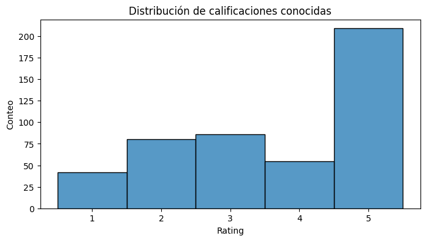

```python
n_ratings = len(ratings)
n_users = ratings["userId"].nunique()
n_songs = ratings["song_id"].nunique()
possible_ratings = n_users * n_songs
sparsity = (n_ratings / possible_ratings)

print(f"\nNúmero de ratings conocidos: {n_ratings}")
print(f"Número de usuarios: {n_users}")
print(f"Número de canciones: {n_songs}")
print(f"Ratings posibles: {possible_ratings}")
print(f"Sparsity: {sparsity:.2f}")

plt.figure(figsize=(8, 4))
sns.histplot(data=ratings, x="rating", discrete=True, color="C0")
plt.title("Distribución de calificaciones conocidas")
plt.xlabel("Rating")
plt.ylabel("Conteo")
plt.show()
```

Se calcularon estadísticas de dispersión de la matriz usuario-canción y se visualizó la distribución de calificaciones.

```python
C = ratings["rating"].mean()
m = ratings.groupby("song_id")["rating"].count().mean()

print(f"\nPromedio global C: {C:.2f}")
print(f"Peso del prior m: {m:.2f}")

def bayesian_avg(song_ratings):
    n = song_ratings.count()
    rating_sum = song_ratings.sum()
    return (C * m + rating_sum) / (m + n)

song_stats = ratings.groupby("song_id").agg(
    rating_mean=("rating", "mean"),
    rating_count=("rating", "count"),
    bayesian_rating=("rating", bayesian_avg)
).reset_index()

song_stats = song_stats.merge(catalogo, on="song_id", how="left")

print("\nTop 10 canciones por promedio bayesiano:")
print(song_stats.sort_values("bayesian_rating", ascending=False).head(10))
```

```
Promedio global C: 3.65
Peso del prior m: 15.73

Top 10 canciones por promedio bayesiano:
       song_id  rating_mean  rating_count  bayesian_rating  \
20  cancion_21     4.260870            23         4.014630
16  cancion_17     4.153846            26         3.965655
6   cancion_07     4.266667            15         3.953362
22  cancion_23     4.120000            25         3.940262
7   cancion_08     4.136364            22         3.935512
5   cancion_06     4.214286            14         3.918161
23  cancion_24     4.133333            15         3.888286
24  cancion_25     3.961538            26         3.845847
8   cancion_09     4.076923            13         3.845708
17  cancion_18     3.812500            16         3.734244
```

[output cut: 24 more lines]

Se implementó el promedio bayesiano para rankear canciones penalizando las que tienen pocas calificaciones.

```python
def create_X(df):
    N = df["userId"].nunique()
    M = df["song_id"].nunique()

    user_mapper = dict(zip(np.unique(df["userId"]), list(range(N))))
    song_mapper = dict(zip(np.unique(df["song_id"]), list(range(M))))

    user_inv_mapper = dict(zip(list(range(N)), np.unique(df["userId"])))
    song_inv_mapper = dict(zip(list(range(M)), np.unique(df["song_id"])))

    user_index = [user_mapper[i] for i in df["userId"]]
    song_index = [song_mapper[i] for i in df["song_id"]]

    X = csr_matrix((df["rating"], (song_index, user_index)), shape=(M, N))

    return X, user_mapper, song_mapper, user_inv_mapper, song_inv_mapper

X, user_mapper, song_mapper, user_inv_mapper, song_inv_mapper = create_X(ratings)

print(f"\nForma de X: {X.shape}")
print("Filas = canciones")
print("Columnas = usuarios")
```

```
Forma de X: (30, 30)
Filas = canciones
Columnas = usuarios
```

Se construyó la matriz dispersa ítem-usuario en formato CSR y se generaron los mapeos entre IDs y sus índices numéricos.

```python
def find_similar_songs(song_id, X, k=5, metric="cosine", show_distance=False):
    song_ind = song_mapper[song_id]
    song_vec = X[song_ind]

    n_neighbors = k + 1

    kNN = NearestNeighbors(n_neighbors=n_neighbors, algorithm="brute", metric=metric)
    kNN.fit(X)

    if isinstance(song_vec, np.ndarray):
        song_vec = song_vec.reshape(1, -1)

    distances, indices = kNN.kneighbors(song_vec, return_distance=True)

    distances = distances.flatten()[1:]
    indices = indices.flatten()[1:]

    similar_song_ids = [song_inv_mapper[i] for i in indices]

    if show_distance:
        return list(zip(similar_song_ids, distances))
    else:
        return similar_song_ids
```

Se definió la función que entrena un modelo KNN con similitud coseno para encontrar canciones con patrones de calificación similares.

```python
print("\nCanciones similares a cancion_07:")
print(display_similar_songs("cancion_07", k=5))
```

```
Canciones similares a cancion_07:
Canción de referencia: Sweet Child O Mine (Rock)
      song_id                         song_title   song_genre  distance  \
0  cancion_06  Everybody Wants To Rule The World         Rock  0.098348
1  cancion_09        Have You Ever Seen The Rain         Rock  0.194120
2  cancion_15               Heroes (we could be)  Electrónica  0.247282
3  cancion_08                    Highway to Hell         Rock  0.267207
4  cancion_11                            Outside  Electrónica  0.275001

   similarity
0    0.901652
1    0.805880
2    0.752718
3    0.732793
4    0.724999
```

Se probó la función de similitud imprimiendo las 5 canciones más parecidas a *cancion_07.*

```python
def recommend_from_song(song_id, k=5):
    recommendations = display_similar_songs(song_id, k=k)
    return recommendations[["song_title", "song_genre", "similarity"]]

print("\nRecomendaciones a partir de cancion_10:")
print(recommend_from_song("cancion_10", k=5))
```

```
Recomendaciones a partir de cancion_10:
Canción de referencia: My Demons (Rock alternativo)
              song_title         song_genre  similarity
0        Highway to Hell               Rock    0.648074
1           Goddard Song     Hip-hop / trap    0.647744
2                    APT                Pop    0.641485
3                Topanga     Hip-hop / trap    0.637251
4  Llamado de emergencia  Urbano / reguetón    0.591389
```

Se construyó la función de recomendación a partir de una canción y se probó con un ejemplo.

```python
def recommend_for_user(user_id, k_neighbors=5, min_rating=4, top_n=10):
    user_ratings = ratings[ratings["userId"] == user_id].copy()

    if user_ratings.empty:
        raise ValueError("Ese user_id no existe en los datos.")

    already_rated = set(user_ratings["song_id"])
    liked = user_ratings[user_ratings["rating"] >= min_rating]

    if liked.empty:
        return pd.DataFrame(columns=["song_id", "song_title", "song_genre", "score"])

    scores = {}

    for _, row in liked.iterrows():
        source_song = row["song_id"]
        source_rating = row["rating"]

        neighbors = find_similar_songs(source_song, X, k=k_neighbors, show_distance=True)

        for neighbor_id, distance in neighbors:
            if neighbor_id in already_rated:
                continue

            similarity = 1 - distance
            scores[neighbor_id] = scores.get(neighbor_id, 0) + (source_rating * similarity)

    if not scores:
        return pd.DataFrame(columns=["song_id", "song_title", "song_genre", "score"])

    recs = pd.DataFrame([{"song_id": sid, "score": score} for sid, score in scores.items()])
    recs = recs.merge(catalogo, on="song_id", how="left")
    recs = recs.sort_values("score", ascending=False).head(top_n)

    return recs[["song_id", "song_title", "song_genre", "score"]]

ratings_por_usuario = ratings.groupby("userId")["song_id"].count().sort_values()
print("\nRatings por usuario (los que menos calificaron):")
print(ratings_por_usuario.head())

primer_usuario = ratings["userId"].unique()[0]
print(f"\nRecomendaciones para usuario {primer_usuario}:")
print(recommend_for_user(primer_usuario, k_neighbors=5, min_rating=4, top_n=10))
```

```
Ratings por usuario (los que menos calificaron):
userId
28.0    7
22.0    8
20.0    8
24.0    8
21.0    9
Name: song_id, dtype: int64

Recomendaciones para usuario 1.0:
      song_id                         song_title         song_genre      score
0  cancion_23                          Me Rehúso  Urbano / reguetón  12.344753
2  cancion_21                               DtMF  Urbano / reguetón   4.046886
1  cancion_06  Everybody Wants To Rule The World               Rock   3.127753
3  cancion_29                              WRONG     Hip-hop / trap   2.719957
```

Se implementó el recomendador por usuario, que toma las canciones mejor calificadas y genera un ranking ponderado de canciones no escuchadas.

```python
usuarios = ratings["userId"].unique()[:30]

for user in usuarios:
    print(f"\nRecomendaciones para usuario {user}")
    print(recommend_for_user(user, k_neighbors=5, min_rating=4, top_n=5))
```

```
Recomendaciones para usuario 1.0
      song_id                         song_title         song_genre      score
0  cancion_23                          Me Rehúso  Urbano / reguetón  12.344753
2  cancion_21                               DtMF  Urbano / reguetón   4.046886
1  cancion_06  Everybody Wants To Rule The World               Rock   3.127753
3  cancion_29                              WRONG     Hip-hop / trap   2.719957

Recomendaciones para usuario 3.0
      song_id        song_title   song_genre      score
1  cancion_14  I’m an Albatraoz  Electrónica  10.729328
0  cancion_02         Stateside          Pop   6.090176

Recomendaciones para usuario 4.0
      song_id          song_title song_genre     score
0  cancion_07  Sweet Child O Mine       Rock  3.606608

Recomendaciones para usuario 5.0
      song_id        song_title         song_genre      score
2  cancion_23         Me Rehúso  Urbano / reguetón  11.481279
0  cancion_14  I’m an Albatraoz        Electrónica   7.796241
1  cancion_18       Ya Borracho  Regional mexicano   7.678144

Recomendaciones para usuario 6.0
      song_id        song_title         song_genre     score
0  cancion_13  Around the World        Electrónica  6.877209
2  cancion_08   Highway to Hell               Rock  6.869435
3  cancion_24       In Da Getto  Urbano / reguetón  3.304727
1  cancion_18       Ya Borracho  Regional mexicano  3.266941

Recomendaciones para usuario 8.0
      song_id                   song_title   song_genre      score
3  cancion_08              Highway to Hell         Rock  11.347244
1  cancion_09  Have You Ever Seen The Rain         Rock   7.696373
0  cancion_11                      Outside  Electrónica   7.421946
2  cancion_15         Heroes (we could be)  Electrónica   3.763590
4  cancion_12                    Play Hard  Electrónica   3.614792

Recomendaciones para usuario 9.0
       song_id                   song_title         song_genre      score
2   cancion_25        Llamado de emergencia  Urbano / reguetón  22.290979
```

[output cut: 143 more lines]

```

Recomendaciones para usuario 28.0
      song_id          song_title         song_genre     score
5  cancion_26      let it breathe     Hip-hop / trap  6.940192
6  cancion_29               WRONG     Hip-hop / trap  6.384096
7  cancion_30  Hard Work Pays Off     Hip-hop / trap  5.934708
2  cancion_16                 dao  Regional mexicano  3.946744
3  cancion_21                DtMF  Urbano / reguetón  3.912337

Recomendaciones para usuario 21.0
      song_id       song_title         song_genre      score
0  cancion_16              dao  Regional mexicano  15.562156
1  cancion_05              APT                Pop   8.296471
3  cancion_12        Play Hard        Electrónica   3.614792
2  cancion_08  Highway to Hell               Rock   3.614068
```

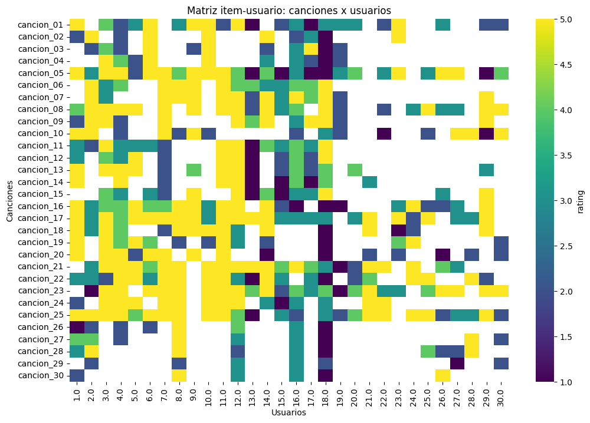

```python
ratings_matrix = ratings.pivot_table(
    index="song_id",
    columns="userId",
    values="rating"
)

plt.figure(figsize=(12, 8))
sns.heatmap(ratings_matrix, cmap="viridis", cbar_kws={"label": "rating"})
plt.title("Matriz item-usuario: canciones x usuarios")
plt.xlabel("Usuarios")
plt.ylabel("Canciones")
plt.show()
```

Se generó un heatmap de la matriz canción-usuario para visualizar gráficamente la dispersión de calificaciones.

```python
!jupyter nbconvert --to html /content/El_recomendador.ipynb
```

```
[NbConvertApp] Converting notebook /content/El_recomendador.ipynb to html
[NbConvertApp] WARNING | Alternative text is missing on 2 image(s).
[NbConvertApp] Writing 465336 bytes to /content/El_recomendador.html
```